# Wine Data Analysis

### Single Layer Network

We first scale our data. Next, we fit our training set to the model. After training our model, we use test set to generate predictions and a confusion matrix with a 0.5 threshold. Finally we plot the ROC curve and calculate its AUC. We could observe that single layer network did not perform really well in wine dataset.

```r
train2 <- train
test2 <- test
train2[,1:11] <- scale(train2[,1:11])
test2[,1:11] <- scale(test2[,1:11])
form1 <- formula(quality ~.)

library(nnet)
set.seed(1)
n1 <- nnet(form1, data=train2, size=3, maxit=500, decay=0.001)
yhat.n1 <- predict(n1, test2)
```

### Confusion Matrix

Plotting confusion matrix for our prediction based on test set.

```r
table(yhat.n1[,1]>0.5, test$quality)
```

```
##
##           0   1
##   FALSE 384  42
##   TRUE   14  23
```

### True Positive Rate (Test Set)

```r
TPR(test$quality, (yhat.n1  > 0.5))
```

```
## [1] 0.3538462
```

### True Negative Rate (Test Set)

```r
TNR(test$quality, (yhat.n1  > 0.5))
```

```
## [1] 0.9648241
```

### Roc Curve

```r
n1.roc <- roc(test$quality, yhat.n1[,1], direction="<")
n1.roc
```

```
##
## Call:
## roc.default(response = test$quality, predictor = yhat.n1[, 1],     direction = "<")
##
## Data: yhat.n1[, 1] in 398 controls (test$quality 0) < 65 cases (test$quality 1).
## Area under the curve: 0.8633
```

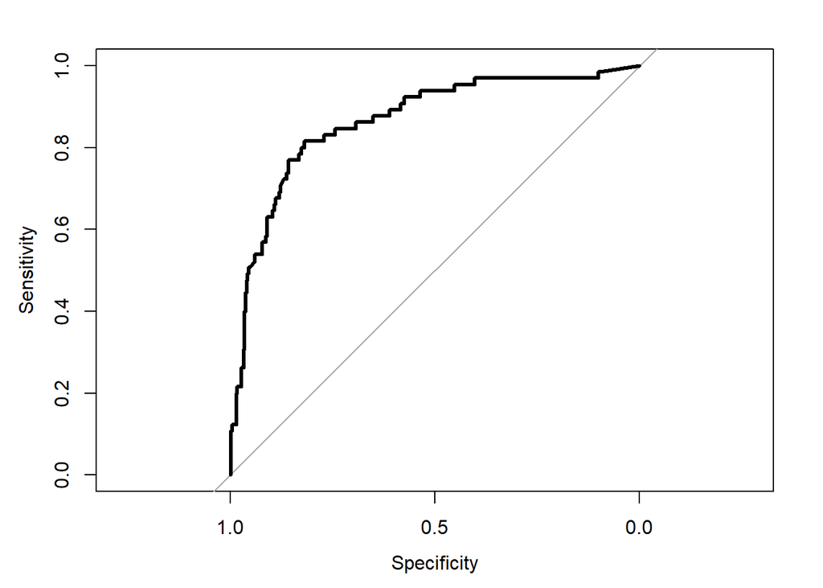

```r
plot(n1.roc, lwd=3)
```

### Multi-Layer Network

```r
library(neuralnet)
dat4 <- model.matrix( ~ quality + fixed.acidity + volatile.acidity +citric.acid +residual.sugar+chlorides+free.sulfur.dioxide+total.sulfur.dioxide+density +pH+ sulphates+alcohol, data = dat)

train4 <- dat4[trn==TRUE,]
train4 <- scale(train4, center = TRUE, scale = TRUE)
test4 <- dat4[trn==FALSE,]
test4 <- scale(test4, center = TRUE, scale = TRUE)

form4 <- as.formula(quality ~ fixed.acidity + volatile.acidity +citric.acid +residual.sugar+chlorides+free.sulfur.dioxide+total.sulfur.dioxide+density +pH+ sulphates+alcohol)
n4 <- neuralnet(form4, data=train4, hidden = c(3,2), linear.output=FALSE)
n4.test <- model.matrix( ~ fixed.acidity + volatile.acidity +citric.acid +residual.sugar+chlorides+free.sulfur.dioxide+total.sulfur.dioxide+density +pH+ sulphates+alcohol, data = as.data.frame(test4))
yhat.n4 <- compute(n4, n4.test[,2:12])
```

### Confusion Matrix

Plotting confusion matrix for our prediction based on test set.

```r
table(yhat.n4$net.result > 0.5, test$quality)
```

```
##
##           0   1
##   FALSE 359  23
##   TRUE   39  42
```

### True Positive Rate (Test Set)

```r
TPR(test$quality, (yhat.n4$net.result  > 0.5))
```

```
## [1] 0.6461538
```

### True Negavtive Rate (Test Set)

```r
TNR(test$quality, (yhat.n4$net.result  > 0.5))
```

```
## [1] 0.9020101
```

### Roc Curve

```r
n4.roc <- roc(test$quality, yhat.n4$net.result, direction="<")
n4.roc
```

```
##
## Call:
## roc.default(response = test$quality, predictor = yhat.n4$net.result,     direction = "<")
##
## Data: yhat.n4$net.result in 398 controls (test$quality 0) < 65 cases (test$quality 1).
## Area under the curve: 0.8765
```

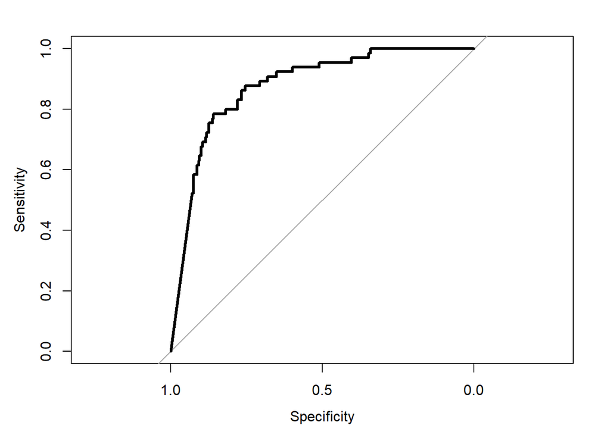

```r
plot(n4.roc,lwd=3)
```

### AUC Comparison

From the left of the plot is glm, lda, qda, classification tree,random forest, gradient boosting, single layer network, and multi-layer network. In conclusion, random forest performs the best in terms of AUC. Single layer network and multi-layer network did not outperform random forest in this case, but multi-layer network performs slightly better than single layer network.

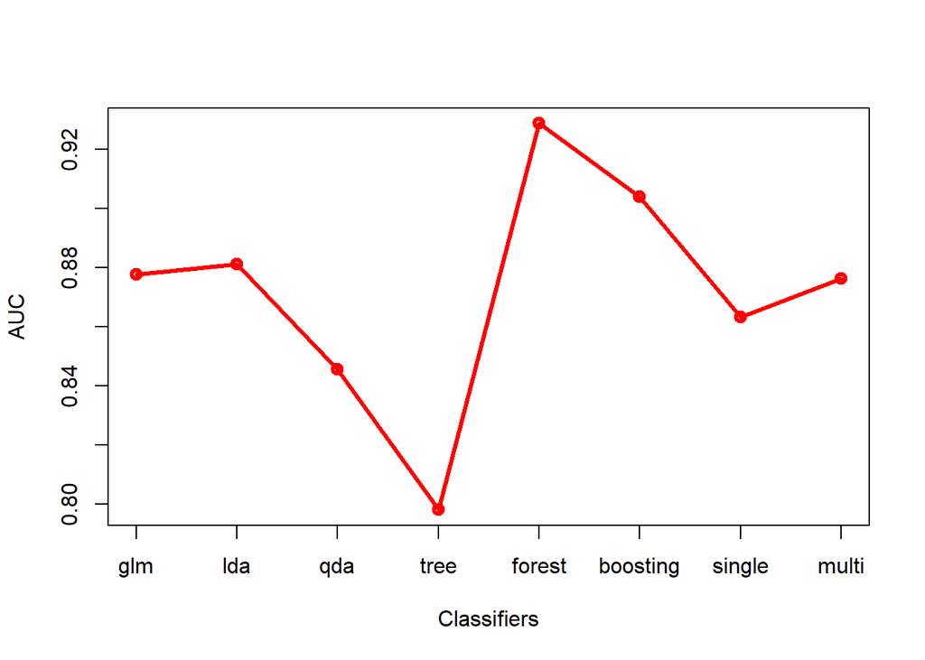

```r
fit_test <- c(auc(glm.roc),auc(lda.roc),auc(qda.roc),auc(t1.roc),auc(rf1.roc),auc(bt1.roc),auc(n1.roc),auc(n4.roc))
plot(fit_test, type="o", lwd=3, col="red",xlab = 'Classifiers',ylab = 'AUC',xaxt = "n")
axis(1,at=c(1:8), labels=c("glm","lda","qda","tree","forest","boosting","single","multi"))
```